# Omics data integration with o2plsda

2025-12-01

# o2plsda: Omics data integration with o2plsda

## Description

*o2plsda* provides functions to do O2PLS-DA analysis for multiple omics integration.The algorithm came from “O2-PLS, a two-block (X±Y) latent variable regression (LVR) method with an integral OSC filter” which published by Johan Trygg and Svante Wold at 2003. O2PLS is a bidirectional multivariate regression method that aims to separate the covariance between two data sets (it was recently extended to multiple data sets) (Löfstedt and Trygg, 2011; Löfstedt et al., 2012) from the systematic sources of variance being specific for each data set separately. It decomposes the variation of two datasets in three parts:

- a joint part that is correlated (predictive) to \(X\) and \(Y\) (i.e. variation related to both \(X\) and \(Y\)), denoted as \(X/Y\) joint variation in \(X\) and \(Y\): \(TW^\top\) and \(UC^\top\),
- a part contained inside \(X/Y\) that is uncorrelated (orthogonal) to \(X\) and \(Y\): \(T_{yosc} W_{yosc} ^\top\) and \(U_{xosc} C_{xosc}^\top\),
- A noise part for \(X\) and \(Y\): \(E_{xy}\) and \(F_{yx}\).

The number of columns in \(T\), \(U\), \(W\) and \(C\) are denoted by as \(nc\) and are referred to as the number of joint components. The number of columns in \(T_{yosc}\) and \(W_{yosc}\) are denoted by as \(nx\) and are referred to as the number of \(X\)-specific components. Analoguous for \(Y\), where we use \(ny\) to denote the number of \(Y\)-specific components. The relation between \(T\) and \(U\) makes the joint part the joint part: \(U = TB_U + H\) or \(U = TB_T'+ H'\). The number of components \((nc, nx, ny)\) are chosen beforehand (e.g. with Cross-Validation).

### Cross-Validation

In order to avoid overfitting of the model, the optimal number of latent variables for each model structure was estimated using group-balanced Monte Carlo cross-validation (MCCV). The package could use the group information when we select the best parameters with cross-validation. In cross-validation (CV) one minimizes a certain measure of error over some parameters that should be determined a priori. Here, we have three parameters: \((nc, nx, ny)\). A popular measure is the prediction error \(||Y - \hat{Y}||\), where \(\hat{Y}\) is a prediction of \(Y\). In our case the O2PLS method is symmetric in \(X\) and \(Y\), so we minimize the sum of the prediction errors: \(||X - \hat{X}||+||Y - \hat{Y}||\).

Here \(nc\) should be a positive integer, and \(nx\) and \(ny\) should be non-negative. The ‘best’ integers are then the minimizers of the prediction error.

The O2PLS-DA analysis was performed as described by Bylesjö et al. (2007); briefly, the O2PLS predictive variation [$TW^\top$, \(UC^\top\)] was used for a subsequent O2PLS-DA analysis. The Variable Importance in the Projection (VIP) value was calculated as a weighted sum of the squared correlations between the OPLS-DA components and the original variable.

## Installation

```r
install.package("o2plsda")
```

## Examples

```r
library(o2plsda)
set.seed(123)
# sample * values
X = matrix(rnorm(5000),50,100)
# sample * values
Y = matrix(rnorm(5000),50,100)
##add sample names
rownames(X) <- paste("S",1:50,sep="")
rownames(Y) <- paste("S",1:50,sep="")
## gene names
colnames(X) <- paste("Gene",1:100,sep="")
colnames(Y) <- paste("Lipid",1:100,sep="")
##scaled
X = scale(X, scale = TRUE)
Y = scale(Y, scale = TRUE)
## group factor could be omitted if you don't have any group
group <- rep(c("Ctrl","Treat"), each = 25)
```

Do cross validation with group information

```r
set.seed(123)
## nr_folds : cross validation k-fold (suggest 10)
## ncores : parallel paramaters for large datasets
cv <- o2cv(X,Y,1:5,1:3,1:3, group = group, nr_folds = 10)
```

```
## #####################################
```

```
## The best parameters are nc = 1, nx = 2, ny = 1
```

```
## #####################################
```

```
## The the RMSE is: 1.97990443734287
```

```
## #####################################
```

Then we can do the O2PLS analysis with nc = 1, nx = 2, ny =1. You can also select the best parameters by looking at the cross validation results.

```r
fit <- o2pls(X,Y,1,2,1)
summary(fit)
```

```
##
## ######### Summary of the O2PLS results #########
## ### Call o2pls(X, Y, nc= 1 , nx= 2 , ny= 1 ) ###
## ### Total variation
## ### X: 4900 ; Y: 4900  ###
## ### Total modeled variation ### X: 0.108 ; Y: 0.098  ###
## ### Joint, Orthogonal, Noise (proportions) ###
##                X     Y
## Joint      0.039 0.052
## Orthogonal 0.070 0.046
## Noise      0.892 0.902
## ### Variation in X joint part predicted by Y Joint part: 0.882
## ### Variation in Y joint part predicted by X Joint part: 0.882
## ### Variation in each Latent Variable (LV) in Joint part:
##     LV1
## X 0.039
## Y 0.052
## ### Variation in each Latent Variable (LV) in X Orthogonal part:
##     LV1   LV2
## X 0.036 0.034
## ### Variation in each Latent Variable (LV) in Y Orthogonal part:
##     LV1
## Y 0.046
##
## ############################################
```

```r
############################################
```

Extract the loadings and scores from the fit results and generated figures

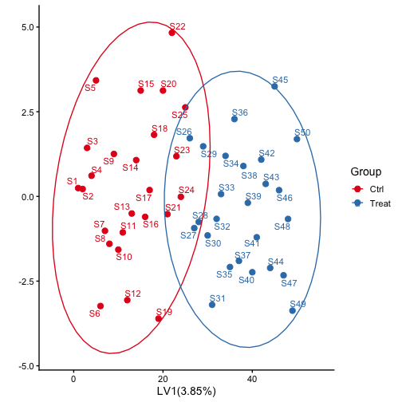

```r
Xl <- loadings(fit,loading="Xjoint")
Xs <- scores(fit,score="Xjoint")
plot(fit,type="score",var="Xjoint", group=group)
```

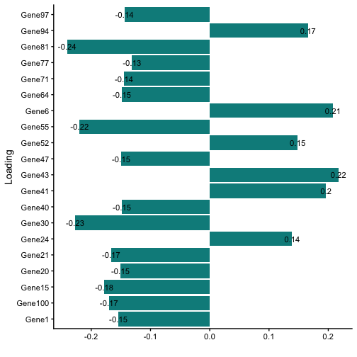

```r
plot(fit,type="loading",var="Xjoint", group=group,repel=F,rotation=TRUE)
```

Do the OPLSDA based on the O2PLS results and calculate the VIP values

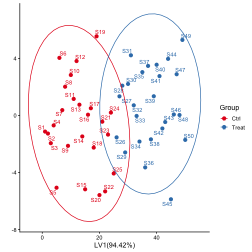

```r
res <- oplsda(fit,group, nc=1)
plot(res,type="score", group=group,repel=TRUE)
```

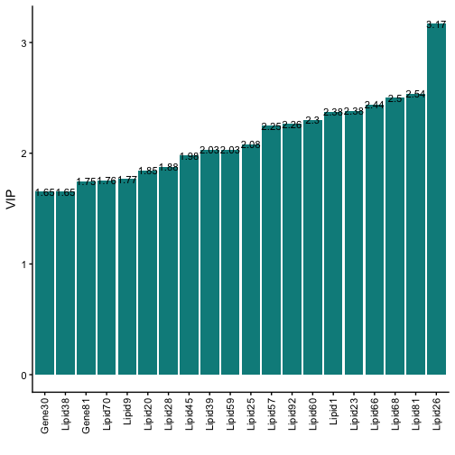

```r
vip <- vip(res)
plot(res,type="vip", group = group, repel = FALSE,order=TRUE)
```

## Citation

If you like this package, please contact me for the citation.

## Contact information

For any questions please contact guokai8@gmail.com or https://github.com/guokai8/o2plsda/issues